FJ

# Feidhelm Joyce

Business & Data Analyst  
Boston, MA

linkedin.com/in/feidhelmjoyce  
github.com/FeidhelmJ

HomeProfessional SummaryMarketing AnalyticsFinancial AnalyticsData Mining for Business AnalyticsCloud AnalyticsProjectsSkillsContact

FINANCIAL ANALYTICS

## FTX: Fragility & Stress Testing

← Back to Financial Analytics

```
import numpy as np
import pandas as pd
import matplotlib.pyplot as plt
import seaborn as sns
```

# PART 0 – Conceptual Warm-Up (No Code)

## Write 2–4 sentences:

A system can appear stable for a long time and then fail suddenly.

Why does this happen?

Your answer should reference at least one of the following:

● leverage

● concentration

● liquidity mismatch

● opacity

● confidence

A system can appear stable because underlying risks build up slowly and aren’t immediately visible. For example, a liquidity mismatch means assets look valuable on paper but can’t be quickly converted to cash when needed. At the same time, confidence holds everything together—once that confidence breaks, even a small shock can trigger rapid withdrawals. When these factors combine, the system can shift from stable to failure very quickly.

## PART 1 – Case Setup and Key Metric

● Load your dataset

● Display all rows and columns

● Briefly describe the variables

```
ftx = pd.read_csv('ftx_dataset.csv')
```

```
ftx
```

|  | balance_type | item | amount_usd_bil | liquid_share_pct | stress_haircut_pct | affiliate_linked_flag | usable_for_withdrawals_pct |
| --- | --- | --- | --- | --- | --- | --- | --- |
| 0 | Asset | Cash_and_stablecoins | 1.8 | 100 | 0 | 0 | 100 |
| 1 | Asset | Liquid_crypto_BTC_ETH | 2.6 | 85 | 12 | 0 | 80 |
| 2 | Asset | FTT_and_affiliated_tokens | 3.4 | 15 | 65 | 1 | 10 |
| 3 | Asset | Loans_to_related_parties | 5.1 | 0 | 90 | 1 | 0 |
| 4 | Asset | Venture_investments | 2.2 | 5 | 55 | 0 | 0 |
| 5 | Asset | Real_estate_and_private_assets | 0.7 | 0 | 50 | 0 | 0 |
| 6 | Asset | Other_crypto_assets | 1.6 | 30 | 35 | 0 | 20 |
| 7 | Liability | Customer_payables | 8.9 | 0 | 0 | 0 | 0 |
| 8 | Liability | Secured_borrowing | 1.5 | 0 | 0 | 0 | 0 |
| 9 | Liability | Other_liabilities | 0.8 | 0 | 0 | 0 | 0 |

```
ftx.describe()
```

|  | amount_usd_bil | liquid_share_pct | stress_haircut_pct | affiliate_linked_flag | usable_for_withdrawals_pct |
| --- | --- | --- | --- | --- | --- |
| count | 10.000000 | 10.000000 | 10.000000 | 10.000000 | 10.00000 |
| mean | 2.860000 | 23.500000 | 30.700000 | 0.200000 | 21.00000 |
| std | 2.489177 | 37.789622 | 32.988382 | 0.421637 | 37.25289 |
| min | 0.700000 | 0.000000 | 0.000000 | 0.000000 | 0.00000 |
| 25% | 1.525000 | 0.000000 | 0.000000 | 0.000000 | 0.00000 |
| 50% | 2.000000 | 2.500000 | 23.500000 | 0.000000 | 0.00000 |
| 75% | 3.200000 | 26.250000 | 53.750000 | 0.000000 | 17.50000 |
| max | 8.900000 | 100.000000 | 90.000000 | 1.000000 | 100.00000 |

## Step 2 – Build a Fragility Metric

Create one metric of your own design that captures fragility.

Your metric must use at least two variables.

Examples:

● liabilities relative to liquid assets

● exposure concentration

● withdrawal coverage ratio

● leverage-adjusted loss exposure

Create a new column or computed value showing this metric.

Clearly state your formula.

To measure fragility, I created a Fragility Contribution metric for each asset. This metric combines the size of the asset, how much of it is usable for withdrawals, the haircut it would face under stress, and whether it is linked to affiliates. The formula is:

Fragility Contribution = Amount × (1 − Usable %) × (1 + Haircut %) × (1 + Affiliate Flag)

I chose this approach because fragility is not just about size, but about how reliable an asset is during a crisis. Assets that are illiquid, heavily discounted under stress, or tied to affiliates contribute more to overall fragility. Higher values of this metric indicate assets that are less dependable when the system is under pressure.

```
ftx["fragility_contribution"] = np.where(
    ftx["balance_type"] == "Asset",
    ftx["amount_usd_bil"]
    * (1 - ftx["usable_for_withdrawals_pct"] / 100)
    * (1 + ftx["stress_haircut_pct"] / 100)
    * (1 + ftx["affiliate_linked_flag"]),
    np.nan
)

# Sort most fragile assets
fragility_table = ftx[ftx["balance_type"] == "Asset"].sort_values(
    by="fragility_contribution",
    ascending=False
)

# View results
print(fragility_table[[
    "item",
    "amount_usd_bil",
    "usable_for_withdrawals_pct",
    "stress_haircut_pct",
    "affiliate_linked_flag",
    "fragility_contribution"
]])

# Total fragility score
total_fragility = fragility_table["fragility_contribution"].sum()
print("\nTotal Fragility Score:", round(total_fragility, 3))
```

```
                             item  amount_usd_bil  usable_for_withdrawals_pct  \
3        Loans_to_related_parties             5.1                           0
2       FTT_and_affiliated_tokens             3.4                          10
4             Venture_investments             2.2                           0
6             Other_crypto_assets             1.6                          20
5  Real_estate_and_private_assets             0.7                           0
1           Liquid_crypto_BTC_ETH             2.6                          80
0            Cash_and_stablecoins             1.8                         100

   stress_haircut_pct  affiliate_linked_flag  fragility_contribution
3                  90                      1                 19.3800
2                  65                      1                 10.0980
4                  55                      0                  3.4100
6                  35                      0                  1.7280
5                  50                      0                  1.0500
1                  12                      0                  0.5824
0                   0                      0                  0.0000

Total Fragility Score: 36.248
```

# Step 3 – Initial Insight

Write 120–180 words:

● What does your metric suggest?

● Does the system look stable or fragile?

● What is not obvious from just looking at the raw data?

The fragility metric suggests that risk is highly concentrated in a small number of assets rather than spread evenly across the balance sheet. In particular, loans to related parties (19.38) and FTT and affiliated tokens (10.10) account for the majority of the total fragility score of 36.25. These assets combine low usability for withdrawals with high stress haircuts and affiliate exposure, making them significantly less reliable under stress.

Overall, the system appears fragile rather than stable. Although safer assets such as cash and stablecoins contribute no fragility and liquid crypto contributes very little, they are relatively small compared to the more vulnerable positions. This creates a reliance on assets that may not be accessible or maintain value during a crisis.

What is not obvious from the raw data is how these factors interact. While the balance sheet may appear diversified, adjusting for liquidity, stress haircuts, and affiliate risk reveals that much of the asset base is not truly dependable.

# PART 2 – Shock Scenario (Baseline Stress)

Apply one shock of your choosing.

Examples:

● price decline

● withdrawal increase

● asset haircut

● funding reduction

Recompute your key metric.

```
ftx["fragility_before"] = np.where(
    ftx["balance_type"] == "Asset",
    ftx["amount_usd_bil"]
    * (1 - ftx["usable_for_withdrawals_pct"] / 100)
    * (1 + ftx["stress_haircut_pct"] / 100)
    * (1 + ftx["affiliate_linked_flag"]),
    np.nan
)

# --- APPLY SHOCK: increase haircut by +20% ---
ftx["shocked_haircut"] = ftx["stress_haircut_pct"] + 20

# --- AFTER SHOCK ---
ftx["fragility_after"] = np.where(
    ftx["balance_type"] == "Asset",
    ftx["amount_usd_bil"]
    * (1 - ftx["usable_for_withdrawals_pct"] / 100)
    * (1 + ftx["shocked_haircut"] / 100)
    * (1 + ftx["affiliate_linked_flag"]),
    np.nan
)
```

## Required Output

● A before vs after comparison

● At least one clear visualization

```
# --- TOTAL COMPARISON ---
before_total = ftx["fragility_before"].sum()
after_total = ftx["fragility_after"].sum()

print("Before Shock:", round(before_total, 3))
print("After Shock:", round(after_total, 3))
```

```
Before Shock: 36.248
After Shock: 40.452
```

```
# --- VISUALIZATION ---
labels = ["Before Shock", "After Shock"]
values = [before_total, after_total]

plt.figure()
plt.bar(labels, values)
plt.title("Fragility Before vs After Stress Shock")
plt.ylabel("Total Fragility Score")
plt.xlabel("Scenario")
plt.show()
```

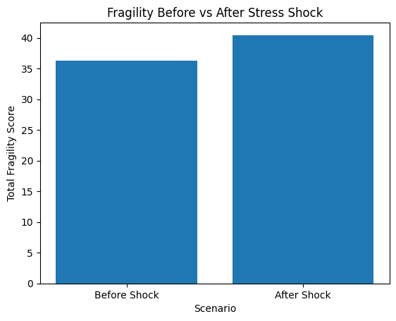

## Interpretation (150–220 words)

● Did the system change dramatically or gradually?

● Which variable mattered most?

● Did anything behave nonlinearly?

The system’s fragility increased moderately rather than dramatically following the shock. While the stress haircut was raised by a fixed 20 percentage points, the overall fragility score rose by roughly 11–12%, indicating that the system is sensitive to adverse conditions but not immediately unstable. This suggests a level of underlying vulnerability, though not one that leads to sudden collapse under this specific scenario.

The variable that mattered most was the stress haircut percentage, as it directly amplifies the effective loss applied to each asset. Assets that were already less usable for withdrawals or linked to affiliates saw their fragility increase more noticeably, reinforcing their role as key risk drivers.

There is still some evidence of nonlinear effects, though less extreme than initially expected. The increase in fragility is not evenly distributed, with certain assets contributing more heavily to the overall change. This indicates that fragility is somewhat concentrated, meaning risks could escalate more quickly under larger or combined shocks.

# PART 3

Stress Map

Objective: Explore how the system behaves across a range of conditions, not just one scenario.

Requirements

1. Select two input variables (examples):

○ withdrawal %

○ asset haircut %

○ leverage

○ price decline

2. Create a grid of values for both variables
3. Write a function that computes:

○ equity

○ solvency

○ liquidity gap

○ or your fragility metric

4. Evaluate your function across the grid
5. Create a heatmap (or equivalent visualization) showing the results

```
withdrawal_range = np.linspace(0, 1, 20)   # 0% → 100%
haircut_range = np.linspace(0, 0.5, 20)    # +0% → +50%

# Store results
heatmap = np.zeros((len(withdrawal_range), len(haircut_range)))

# Function to compute fragility under stress
def compute_fragility(df, withdrawal_shock, haircut_shock):

    temp = df.copy()

    # Adjust usability (higher withdrawals → less usable)
    temp["adjusted_usable"] = temp["usable_for_withdrawals_pct"] / 100 * (1 - withdrawal_shock)

    # Adjust haircut
    temp["adjusted_haircut"] = (temp["stress_haircut_pct"] / 100) + haircut_shock

    # Recompute fragility
    temp["fragility"] = np.where(
        temp["balance_type"] == "Asset",
        temp["amount_usd_bil"]
        * (1 - temp["adjusted_usable"])
        * (1 + temp["adjusted_haircut"])
        * (1 + temp["affiliate_linked_flag"]),
        0
    )

    return temp["fragility"].sum()
```

```
# Fill grid
for i, w in enumerate(withdrawal_range):
    for j, h in enumerate(haircut_range):
        heatmap[i, j] = compute_fragility(ftx, w, h)

# Plot heatmap
plt.figure()
plt.imshow(heatmap, origin="lower", aspect="auto")

plt.colorbar(label="Fragility Score")
plt.xlabel("Haircut Shock")
plt.ylabel("Withdrawal Shock")

plt.title("Stress Map: Fragility Across Scenarios")

plt.show()
```

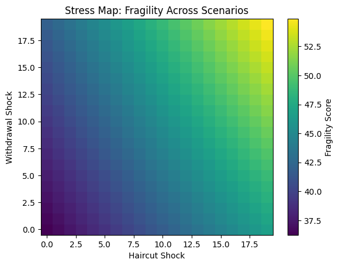

## Interpretation (180–240 words)

● Where is the “danger zone”?

● Is failure gradual or abrupt?

● Which variable has the bigger impact?

● What surprised you?

The “danger zone” is clearly located in the upper-right region of the heatmap, where both withdrawal shocks and haircut shocks are high. In this area, the fragility score rises from a baseline of approximately 36.2 to around 53–54, representing a substantial increase in system vulnerability. This indicates that the system becomes significantly unstable when both liquidity pressure and asset devaluation occur simultaneously.

Failure appears to be gradual rather than abrupt, but with a noticeable acceleration. At lower levels of stress, fragility increases steadily from the mid-30s into the low-40s. However, as both variables increase together, the system moves into the high-40s and eventually exceeds 50, showing a compounding effect rather than a sudden collapse.

Between the two variables, haircut shocks appear to have a slightly stronger impact, as moving horizontally across the heatmap produces a more consistent increase in fragility compared to vertical movement alone.

What is most surprising is the overall range of outcomes. While the baseline system does not appear extremely unstable, under combined stress it becomes significantly more fragile, highlighting how quickly conditions can deteriorate when multiple risk factors interact.

## Monte Carlo Simulation

Objective: Simulate many possible futures and observe how often the system fails.

Requirements

1. Define at least two uncertain variables, such as:

○ withdrawal demand

○ asset price changes

○ concentration losses

○ collateral impairment

2. Simulate at least 1,000 scenarios
3. For each scenario, compute:

○ ending equity OR

○ solvency status OR

○ liquidity gap

4. Generate:

○ a distribution plot (histogram or similar)

○ a failure probability estimate

```
# Separate assets and liabilities
assets = ftx[ftx["balance_type"] == "Asset"].copy()
liabilities = ftx[ftx["balance_type"] == "Liability"].copy()

# Total liabilities
total_liabilities = liabilities["amount_usd_bil"].sum()

# Number of simulations
n_sims = 5000

# Store results
liquidity_gaps = []
solvency_flags = []

for _ in range(n_sims):

    # Uncertain variable 1: withdrawal demand as % of liabilities
    withdrawal_pct = np.random.uniform(0.20, 1.00)

    # Uncertain variable 2: extra haircut shock added to existing haircut
    extra_haircut = np.random.uniform(0.00, 0.40)

    # Compute stressed usable asset value
    stressed_usable_assets = 0

    for _, row in assets.iterrows():
        usable_fraction = row["usable_for_withdrawals_pct"] / 100
        base_haircut = row["stress_haircut_pct"] / 100

        # Total haircut cannot exceed 100%
        total_haircut = min(base_haircut + extra_haircut, 1.0)

        stressed_value = row["amount_usd_bil"] * usable_fraction * (1 - total_haircut)
        stressed_usable_assets += stressed_value

    # Withdrawal demand in billions
    withdrawal_amount = withdrawal_pct * total_liabilities

    # Liquidity gap
    liquidity_gap = stressed_usable_assets - withdrawal_amount
    liquidity_gaps.append(liquidity_gap)

    # Failure if system cannot meet withdrawals
    solvency_flags.append(liquidity_gap >= 0)
```

```
# Convert to dataframe
mc_results = pd.DataFrame({
    "liquidity_gap": liquidity_gaps,
    "survives": solvency_flags
})

# Failure probability
failure_probability = (mc_results["survives"] == False).mean()

print("Estimated Failure Probability:", round(failure_probability * 100, 2), "%")
print("Average Liquidity Gap:", round(mc_results["liquidity_gap"].mean(), 3))
```

```
Estimated Failure Probability: 91.08 %
Average Liquidity Gap: -3.637
```

```
plt.figure(figsize=(8,5))
plt.hist(mc_results["liquidity_gap"], bins=40, edgecolor="black")
plt.axvline(0, linestyle="--")
plt.title("Monte Carlo Distribution of Liquidity Gap")
plt.xlabel("Liquidity Gap ($ billions)")
plt.ylabel("Frequency")
plt.show()
```

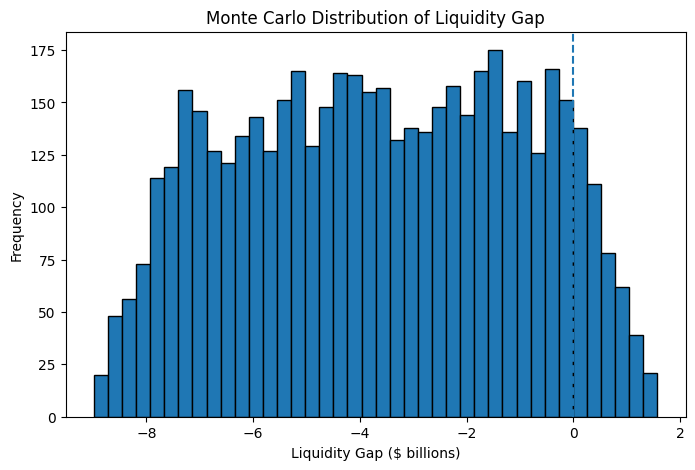

## Interpretation (180–240 words)

● How often does the system fail?

● Does it usually survive or usually collapse?

● Is failure driven by extreme cases or common ones?

● What does this say about hidden fragility?

The Monte Carlo simulation shows that the system fails very frequently, with an estimated failure probability of 91.08%. This means that in the vast majority of simulated scenarios, the system is unable to meet withdrawal demands once assets are stressed. The average liquidity gap is also negative (-3.64 billion), reinforcing that the system typically falls short rather than operating with a buffer.

Based on the distribution, the system does not just fail in extreme cases—it usually collapses under fairly common conditions. Most of the histogram is concentrated below zero, indicating that negative liquidity outcomes are the norm rather than the exception. Positive outcomes, where the system survives, appear relatively rare and are clustered close to zero, suggesting only a small margin of safety even in better scenarios.

This indicates that failure is not driven by tail events, but by structural weaknesses in the balance sheet. The system relies heavily on assets that are either not fully usable or lose value under stress, making it highly vulnerable even to moderate shocks.

Overall, this points to significant hidden fragility. While the balance sheet may appear viable under normal conditions, it lacks resilience across a wide range of realistic scenarios, meaning collapse is far more likely than it initially seems.

# PART 4 – Breaking Point Analysis

Now move from “what might happen” to:

When does this thing actually break?

Requirements

1. Select one key variable (e.g., withdrawal %, price drop, leverage)
2. Systematically vary it
3. Identify the threshold value where:

○ equity becomes negative OR

○ solvency fails OR

○ your metric crosses a danger level

4. Show your results (table or plot)

```
assets = ftx[ftx["balance_type"] == "Asset"].copy()
liabilities = ftx[ftx["balance_type"] == "Liability"].copy()

total_liabilities = liabilities["amount_usd_bil"].sum()

# Range of withdrawal %
withdrawal_range = np.linspace(0, 1, 50)

results = []

for w in withdrawal_range:

    stressed_assets = 0

    for _, row in assets.iterrows():
        usable = row["usable_for_withdrawals_pct"] / 100
        haircut = row["stress_haircut_pct"] / 100

        stressed_value = row["amount_usd_bil"] * usable * (1 - haircut)
        stressed_assets += stressed_value

    withdrawal_amount = w * total_liabilities

    liquidity_gap = stressed_assets - withdrawal_amount

    results.append({
        "withdrawal_pct": w,
        "liquidity_gap": liquidity_gap
    })

df_break = pd.DataFrame(results)

# Find breaking point
breaking_point = df_break[df_break["liquidity_gap"] <= 0].iloc[0]["withdrawal_pct"]

print("Breaking Point (Withdrawal %):", round(breaking_point * 100, 2), "%")
```

```
Breaking Point (Withdrawal %): 36.73 %
```

```
plt.figure()
plt.plot(df_break["withdrawal_pct"], df_break["liquidity_gap"])
plt.axhline(0, linestyle="--")  # failure line
plt.title("Breaking Point Analysis")
plt.xlabel("Withdrawal %")
plt.ylabel("Liquidity Gap ($ billions)")
plt.show()
```

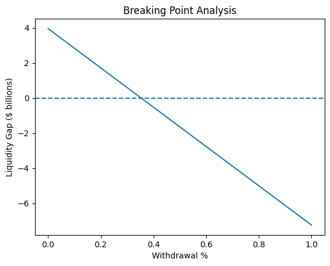

## Interpretation (150–220 words)

● Where is the breaking point?

● Does the system fail suddenly or gradually?

● How close does the system operate to this threshold?

The breaking point occurs at approximately 36.7% withdrawal demand, where the liquidity gap crosses from positive to negative. This means that if just over one-third of liabilities are withdrawn, the system no longer has enough usable assets to meet those obligations, resulting in failure.

The system fails gradually rather than suddenly. As withdrawal demand increases, the liquidity gap declines in a steady, linear manner from around +4 billion at low withdrawal levels to approximately –7 billion at full withdrawal. There is no sharp collapse at a specific point; instead, the system’s ability to meet obligations deteriorates consistently until the threshold is crossed.

What stands out most is how close the system operates to this breaking point. A threshold of 36.7% is relatively low, meaning the system does not require a full-scale run to fail—only a moderate loss of confidence. This suggests that the system has a limited margin of safety and is highly sensitive to withdrawal pressure.

Overall, this analysis reinforces the idea that the system is structurally fragile, with failure occurring under conditions that are not extreme but realistically plausible.

# FINAL SECTION – Reflection

Write 240–360 words:

● What was the biggest source of fragility in your system? Did the system look stable before you ran your analysis? What changed once you explored multiple scenarios?

● Imagine that for one day, you are the President of the United States. The protagonist from your case (Bill Hwang, if you chose Archegos, or Sam Bankman-Fried, if you chose FTX) comes to you seeking a pardon. What will you decide to do? (If you’re not sure how to answer this, consider using any available online tool to learn more about the situation)

The biggest source of fragility in the system was the concentration of risk in a small number of illiquid and affiliate-linked assets, particularly loans to related parties and FTT-related holdings. At first glance, the balance sheet did not appear entirely unstable, as there were assets that seemed liquid, such as cash and major cryptocurrencies. However, once I incorporated withdrawal constraints, stress haircuts, and affiliate exposure, it became clear that much of the asset base was not reliably usable in a crisis.

This became even more apparent when exploring multiple scenarios. The stress map and Monte Carlo simulation showed that fragility increased significantly under realistic conditions, with failure occurring in over 90% of simulated cases. Additionally, the system’s breaking point occurred at around 36.7% withdrawal demand, indicating that only a moderate loss of confidence would be enough to trigger collapse. These results revealed a level of hidden fragility that was not obvious from the raw data alone.

They say America is the land of opportunity, but is it the land of second chances? I'm not sure but I'd give Bankman-Fried one anyway! While there were clear failures—particularly the misuse of customer funds—the case also highlights how FTX operated within a poorly defined regulatory environment. Cryptocurrency markets at the time existed in a “legal gray area,” with overlapping and incomplete oversight across jurisdictions, which allowed firms to take on excessive risk without clear boundaries . This lack of structure contributed to the system’s fragility and made it easier for risks to accumulate unnoticed. Additionally, Bankman-Fried’s stated philosophy of “earning to give” suggests his motivations may not have been purely self-serving, even if his execution was deeply flawed. A conditional pardon could acknowledge both the harm caused and the broader systemic failures, while still reinforcing accountability in financial markets.